# Unsupervised Learning: Trade&Ahead

**Marks: 60**

### Context

The stock market has consistently proven to be a good place to invest in and save for the future. There are a lot of compelling reasons to invest in stocks. It can help in fighting inflation, create wealth, and also provides some tax benefits. Good steady returns on investments over a long period of time can also grow a lot more than seems possible. Also, thanks to the power of compound interest, the earlier one starts investing, the larger the corpus one can have for retirement. Overall, investing in stocks can help meet life's financial aspirations.

It is important to maintain a diversified portfolio when investing in stocks in order to maximise earnings under any market condition. Having a diversified portfolio tends to yield higher returns and face lower risk by tempering potential losses when the market is down. It is often easy to get lost in a sea of financial metrics to analyze while determining the worth of a stock, and doing the same for a multitude of stocks to identify the right picks for an individual can be a tedious task. By doing a cluster analysis, one can identify stocks that exhibit similar characteristics and ones which exhibit minimum correlation. This will help investors better analyze stocks across different market segments and help protect against risks that could make the portfolio vulnerable to losses.

### Objective

Trade&Ahead is a financial consultancy firm who provide their customers with personalized investment strategies. They have hired you as a Data Scientist and provided you with data comprising stock price and some financial indicators for a few companies listed under the New York Stock Exchange. They have assigned you the tasks of analyzing the data, grouping the stocks based on the attributes provided, and sharing insights about the characteristics of each group.

### Data Dictionary

- Ticker Symbol: An abbreviation used to uniquely identify publicly traded shares of a particular stock on a particular stock market
- Company: Name of the company
- GICS Sector: The specific economic sector assigned to a company by the Global Industry Classification Standard (GICS) that best defines its business operations
- GICS Sub Industry: The specific sub-industry group assigned to a company by the Global Industry Classification Standard (GICS) that best defines its business operations
- Current Price: Current stock price in dollars
- Price Change: Percentage change in the stock price in 13 weeks
- Volatility: Standard deviation of the stock price over the past 13 weeks
- ROE: A measure of financial performance calculated by dividing net income by shareholders' equity (shareholders' equity is equal to a company's assets minus its debt)
- Cash Ratio: The ratio of a company's total reserves of cash and cash equivalents to its total current liabilities
- Net Cash Flow: The difference between a company's cash inflows and outflows (in dollars)
- Net Income: Revenues minus expenses, interest, and taxes (in dollars)
- Earnings Per Share: Company's net profit divided by the number of common shares it has outstanding (in dollars)
- Estimated Shares Outstanding: Company's stock currently held by all its shareholders
- P/E Ratio: Ratio of the company's current stock price to the earnings per share
- P/B Ratio: Ratio of the company's stock price per share by its book value per share (book value of a company is the net difference between that company's total assets and total liabilities)

## Importing necessary libraries and data

```python
from google.colab import drive
drive.mount('/content/drive')
```

```python
import pandas as pd
import numpy as np
import seaborn as sns
import matplotlib.pyplot as plt
pd.set_option("display.max_columns", None)
pd.set_option("display.max_rows", 200)
from sklearn.preprocessing import StandardScaler
from sklearn.cluster import KMeans
from sklearn.cluster import AgglomerativeClustering
from sklearn.metrics import silhouette_score
from sklearn.decomposition import PCA
from scipy.spatial.distance import cdist, pdist
from yellowbrick.cluster import KElbowVisualizer, SilhouetteVisualizer
from scipy.cluster.hierarchy import dendrogram, linkage, cophenet
import warnings
warnings.filterwarnings("ignore")
```

```python
Stock_data = pd.read_csv("/content/drive/MyDrive/stock_data.csv")
df_SD = Stock_data.copy()
```

## Data Overview

- Observations
- Sanity checks

```python
df_SD.head()
```

|  | Ticker Symbol | Security | GICS Sector | GICS Sub Industry | Current Price | Price Change | Volatility | ROE | Cash Ratio | Net Cash Flow | Net Income | Earnings Per Share | Estimated Shares Outstanding | P/E Ratio | P/B Ratio |
| --- | --- | --- | --- | --- | --- | --- | --- | --- | --- | --- | --- | --- | --- | --- | --- |
| 0 | AAL | American Airlines Group | Industrials | Airlines | 42.349998 | 9.999995 | 1.687151 | 135 | 51 | -604000000 | 7610000000 | 11.39 | 6.681299e+08 | 3.718174 | -8.784219 |
| 1 | ABBV | AbbVie | Health Care | Pharmaceuticals | 59.240002 | 8.339433 | 2.197887 | 130 | 77 | 51000000 | 5144000000 | 3.15 | 1.633016e+09 | 18.806350 | -8.750068 |
| 2 | ABT | Abbott Laboratories | Health Care | Health Care Equipment | 44.910000 | 11.301121 | 1.273646 | 21 | 67 | 938000000 | 4423000000 | 2.94 | 1.504422e+09 | 15.275510 | -0.394171 |
| 3 | ADBE | Adobe Systems Inc | Information Technology | Application Software | 93.940002 | 13.977195 | 1.357679 | 9 | 180 | -240840000 | 629551000 | 1.26 | 4.996437e+08 | 74.555557 | 4.199651 |
| 4 | ADI | Analog Devices, Inc. | Information Technology | Semiconductors | 55.320000 | -1.827858 | 1.701169 | 14 | 272 | 315120000 | 696878000 | 0.31 | 2.247994e+09 | 178.451613 | 1.059810 |

```python
df_SD.tail()
```

|  | Ticker Symbol | Security | GICS Sector | GICS Sub Industry | Current Price | Price Change | Volatility | ROE | Cash Ratio | Net Cash Flow | Net Income | Earnings Per Share | Estimated Shares Outstanding | P/E Ratio | P/B Ratio |
| --- | --- | --- | --- | --- | --- | --- | --- | --- | --- | --- | --- | --- | --- | --- | --- |
| 335 | YHOO | Yahoo Inc. | Information Technology | Internet Software & Services | 33.259998 | 14.887727 | 1.845149 | 15 | 459 | -1032187000 | -4359082000 | -4.64 | 939457327.6 | 28.976191 | 6.261775 |
| 336 | YUM | Yum! Brands Inc | Consumer Discretionary | Restaurants | 52.516175 | -8.698917 | 1.478877 | 142 | 27 | 159000000 | 1293000000 | 2.97 | 435353535.4 | 17.682214 | -3.838260 |
| 337 | ZBH | Zimmer Biomet Holdings | Health Care | Health Care Equipment | 102.589996 | 9.347683 | 1.404206 | 1 | 100 | 376000000 | 147000000 | 0.78 | 188461538.5 | 131.525636 | -23.884449 |
| 338 | ZION | Zions Bancorp | Financials | Regional Banks | 27.299999 | -1.158588 | 1.468176 | 4 | 99 | -43623000 | 309471000 | 1.20 | 257892500.0 | 22.749999 | -0.063096 |
| 339 | ZTS | Zoetis | Health Care | Pharmaceuticals | 47.919998 | 16.678836 | 1.610285 | 32 | 65 | 272000000 | 339000000 | 0.68 | 498529411.8 | 70.470585 | 1.723068 |

```python
df_SD.shape
```

```
(340, 15)
```

- The dataset has 340 rows and 15 columns.

```python
df_SD.info()
```

```
<class 'pandas.core.frame.DataFrame'>
RangeIndex: 340 entries, 0 to 339
Data columns (total 15 columns):
 #   Column                        Non-Null Count  Dtype
---  ------                        --------------  -----
 0   Ticker Symbol                 340 non-null    object
 1   Security                      340 non-null    object
 2   GICS Sector                   340 non-null    object
 3   GICS Sub Industry             340 non-null    object
 4   Current Price                 340 non-null    float64
 5   Price Change                  340 non-null    float64
 6   Volatility                    340 non-null    float64
 7   ROE                           340 non-null    int64
 8   Cash Ratio                    340 non-null    int64
 9   Net Cash Flow                 340 non-null    int64
 10  Net Income                    340 non-null    int64
 11  Earnings Per Share            340 non-null    float64
 12  Estimated Shares Outstanding  340 non-null    float64
 13  P/E Ratio                     340 non-null    float64
 14  P/B Ratio                     340 non-null    float64
dtypes: float64(7), int64(4), object(4)
memory usage: 40.0+ KB
```

- There are 4 object, 7 float64 and 4 int64 data types.

```python
df_SD.copy()
```

|  | Ticker Symbol | Security | GICS Sector | GICS Sub Industry | Current Price | Price Change | Volatility | ROE | Cash Ratio | Net Cash Flow | Net Income | Earnings Per Share | Estimated Shares Outstanding | P/E Ratio | P/B Ratio |
| --- | --- | --- | --- | --- | --- | --- | --- | --- | --- | --- | --- | --- | --- | --- | --- |
| 0 | AAL | American Airlines Group | Industrials | Airlines | 42.349998 | 9.999995 | 1.687151 | 135 | 51 | -604000000 | 7610000000 | 11.39 | 6.681299e+08 | 3.718174 | -8.784219 |
| 1 | ABBV | AbbVie | Health Care | Pharmaceuticals | 59.240002 | 8.339433 | 2.197887 | 130 | 77 | 51000000 | 5144000000 | 3.15 | 1.633016e+09 | 18.806350 | -8.750068 |
| 2 | ABT | Abbott Laboratories | Health Care | Health Care Equipment | 44.910000 | 11.301121 | 1.273646 | 21 | 67 | 938000000 | 4423000000 | 2.94 | 1.504422e+09 | 15.275510 | -0.394171 |
| 3 | ADBE | Adobe Systems Inc | Information Technology | Application Software | 93.940002 | 13.977195 | 1.357679 | 9 | 180 | -240840000 | 629551000 | 1.26 | 4.996437e+08 | 74.555557 | 4.199651 |
| 4 | ADI | Analog Devices, Inc. | Information Technology | Semiconductors | 55.320000 | -1.827858 | 1.701169 | 14 | 272 | 315120000 | 696878000 | 0.31 | 2.247994e+09 | 178.451613 | 1.059810 |
| ... | ... | ... | ... | ... | ... | ... | ... | ... | ... | ... | ... | ... | ... | ... | ... |
| 335 | YHOO | Yahoo Inc. | Information Technology | Internet Software & Services | 33.259998 | 14.887727 | 1.845149 | 15 | 459 | -1032187000 | -4359082000 | -4.64 | 9.394573e+08 | 28.976191 | 6.261775 |
| 336 | YUM | Yum! Brands Inc | Consumer Discretionary | Restaurants | 52.516175 | -8.698917 | 1.478877 | 142 | 27 | 159000000 | 1293000000 | 2.97 | 4.353535e+08 | 17.682214 | -3.838260 |
| 337 | ZBH | Zimmer Biomet Holdings | Health Care | Health Care Equipment | 102.589996 | 9.347683 | 1.404206 | 1 | 100 | 376000000 | 147000000 | 0.78 | 1.884615e+08 | 131.525636 | -23.884449 |
| 338 | ZION | Zions Bancorp | Financials | Regional Banks | 27.299999 | -1.158588 | 1.468176 | 4 | 99 | -43623000 | 309471000 | 1.20 | 2.578925e+08 | 22.749999 | -0.063096 |
| 339 | ZTS | Zoetis | Health Care | Pharmaceuticals | 47.919998 | 16.678836 | 1.610285 | 32 | 65 | 272000000 | 339000000 | 0.68 | 4.985294e+08 | 70.470585 | 1.723068 |

340 rows × 15 columns

```python
df_SD.duplicated().sum()
```

```
0
```

```python
df_SD.isnull().sum()
```

```
Ticker Symbol                   0
Security                        0
GICS Sector                     0
GICS Sub Industry               0
Current Price                   0
Price Change                    0
Volatility                      0
ROE                             0
Cash Ratio                      0
Net Cash Flow                   0
Net Income                      0
Earnings Per Share              0
Estimated Shares Outstanding    0
P/E Ratio                       0
P/B Ratio                       0
dtype: int64
```

```python
df_SD.describe().T
```

|  | count | mean | std | min | 25% | 50% | 75% | max |
| --- | --- | --- | --- | --- | --- | --- | --- | --- |
| Current Price | 340.0 | 8.086234e+01 | 9.805509e+01 | 4.500000e+00 | 3.855500e+01 | 5.970500e+01 | 9.288000e+01 | 1.274950e+03 |
| Price Change | 340.0 | 4.078194e+00 | 1.200634e+01 | -4.712969e+01 | -9.394838e-01 | 4.819505e+00 | 1.069549e+01 | 5.505168e+01 |
| Volatility | 340.0 | 1.525976e+00 | 5.917984e-01 | 7.331632e-01 | 1.134878e+00 | 1.385593e+00 | 1.695549e+00 | 4.580042e+00 |
| ROE | 340.0 | 3.959706e+01 | 9.654754e+01 | 1.000000e+00 | 9.750000e+00 | 1.500000e+01 | 2.700000e+01 | 9.170000e+02 |
| Cash Ratio | 340.0 | 7.002353e+01 | 9.042133e+01 | 0.000000e+00 | 1.800000e+01 | 4.700000e+01 | 9.900000e+01 | 9.580000e+02 |
| Net Cash Flow | 340.0 | 5.553762e+07 | 1.946365e+09 | -1.120800e+10 | -1.939065e+08 | 2.098000e+06 | 1.698108e+08 | 2.076400e+10 |
| Net Income | 340.0 | 1.494385e+09 | 3.940150e+09 | -2.352800e+10 | 3.523012e+08 | 7.073360e+08 | 1.899000e+09 | 2.444200e+10 |
| Earnings Per Share | 340.0 | 2.776662e+00 | 6.587779e+00 | -6.120000e+01 | 1.557500e+00 | 2.895000e+00 | 4.620000e+00 | 5.009000e+01 |
| Estimated Shares Outstanding | 340.0 | 5.770283e+08 | 8.458496e+08 | 2.767216e+07 | 1.588482e+08 | 3.096751e+08 | 5.731175e+08 | 6.159292e+09 |
| P/E Ratio | 340.0 | 3.261256e+01 | 4.434873e+01 | 2.935451e+00 | 1.504465e+01 | 2.081988e+01 | 3.176476e+01 | 5.280391e+02 |
| P/B Ratio | 340.0 | -1.718249e+00 | 1.396691e+01 | -7.611908e+01 | -4.352056e+00 | -1.067170e+00 | 3.917066e+00 | 1.290646e+02 |

## Exploratory Data Analysis (EDA)

- EDA is an important part of any project involving data.
- It is important to investigate and understand the data better before building a model with it.
- A few questions have been mentioned below which will help you approach the analysis in the right manner and generate insights from the data.
- A thorough analysis of the data, in addition to the questions mentioned below, should be done.

**Questions**:

1. What does the distribution of stock prices look like?
2. The stocks of which economic sector have seen the maximum price increase on average?
3. How are the different variables correlated with each other?
4. Cash ratio provides a measure of a company's ability to cover its short-term obligations using only cash and cash equivalents. How does the average cash ratio vary across economic sectors?
5. P/E ratios can help determine the relative value of a company's shares as they signify the amount of money an investor is willing to invest in a single share of a company per dollar of its earnings. How does the P/E ratio vary, on average, across economic sectors?

```python
def histogram_boxplot(data, feature, figsize=(15, 10), kde=False, bins=None):
    f2, (ax_box2, ax_hist2) = plt.subplots(nrows=2, sharex=True, gridspec_kw={"height_ratios": (0.25, 0.75)}, figsize=figsize,)
    sns.boxplot(data=data, x=feature, ax=ax_box2, showmeans=True, color="violet")
    sns.histplot(data=data, x=feature, kde=kde, ax=ax_hist2, bins=bins) if bins else sns.histplot(data=data, x=feature, kde=kde, ax=ax_hist2)
    ax_hist2.axvline(data[feature].mean(), color="green", linestyle="--")
    ax_hist2.axvline(data[feature].median(), color="black", linestyle="-")
```

```python
def labeled_barplot(data, feature, perc=False, n=None):
    total = len(data[feature])
    count = data[feature].nunique()
    if n is None:
        plt.figure(figsize=(count + 2, 6))
    else:
        plt.figure(figsize=(n + 2, 6))
    plt.xticks(rotation=90, fontsize=15)
    ax = sns.countplot(data=data,x=feature,palette="Paired",order=data[feature].value_counts().index[:n],)
    for p in ax.patches:
        if perc == True:
            label = "{:.1f}%".format(100 * p.get_height() / total)
        else:
            label = p.get_height()
        x = p.get_x() + p.get_width() / 2
        y = p.get_height()
        ax.annotate(label,(x, y),ha="center",va="center",size=12,xytext=(0, 5),textcoords="offset points",)
    plt.show()
```

```python
def stacked_barplot(data, predictor, target):
    count = data[predictor].nunique()
    sorter = data[target].value_counts().index[-1]
    tab1 = pd.crosstab(data[predictor], data[target], margins=True).sort_values(by=sorter, ascending=False)
    print(tab1)
    print("-" * 120)
    tab = pd.crosstab(data[predictor], data[target], normalize="index").sort_values(by=sorter, ascending=False)
    tab.plot(kind="bar", stacked=True, figsize=(count + 5, 5))
    plt.legend(loc="lower left", frameon=False,)
    plt.legend(loc="upper left", bbox_to_anchor=(1, 1))
    plt.show()
```

```python
def distribution_plot_wrt_target(data, predictor, target):
    fig, axs = plt.subplots(2, 2, figsize=(12, 10))
    target_uniq = data[target].unique()
    axs[0, 0].set_title("Distribution of target for target=" + str(target_uniq[0]))
    sns.histplot(data=data[data[target] == target_uniq[0]],x=predictor,kde=True,ax=axs[0, 0],color="teal",stat="density",)
    axs[0, 1].set_title("Distribution of target for target=" + str(target_uniq[1]))
    sns.histplot(data=data[data[target] == target_uniq[1]],x=predictor,kde=True,ax=axs[0, 1],color="orange",stat="density",)
    axs[1, 0].set_title("Boxplot w.r.t target")
    sns.boxplot(data=data, x=target, y=predictor, ax=axs[1, 0], palette="gist_rainbow")
    axs[1, 1].set_title("Boxplot (without outliers) w.r.t target")
    sns.boxplot(data=data,x=target,y=predictor,ax=axs[1, 1],showfliers=False,palette="gist_rainbow",)
    plt.tight_layout()
    plt.show()
```

**Univariate Analysis**

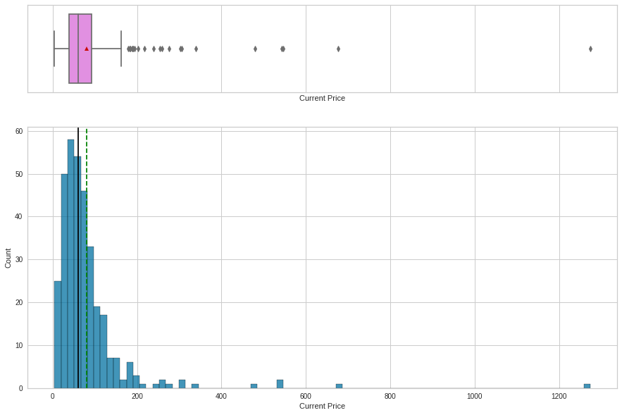

```python
histogram_boxplot(df_SD, "Current Price")
```

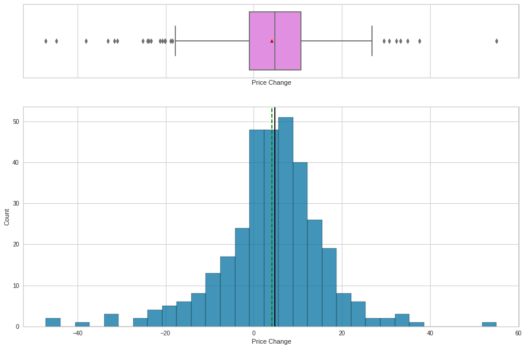

```python
histogram_boxplot(df_SD, "Price Change")
```

- The average price change seems to be a little above 0

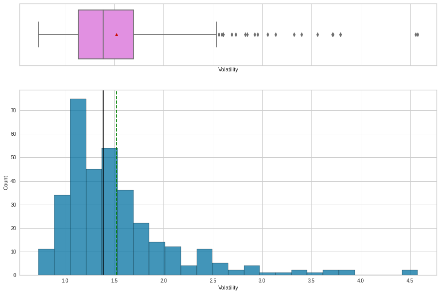

```python
histogram_boxplot(df_SD, "Volatility")
```

- The average volatility is a little under 1.5.
- The outliers are only above 2.5.

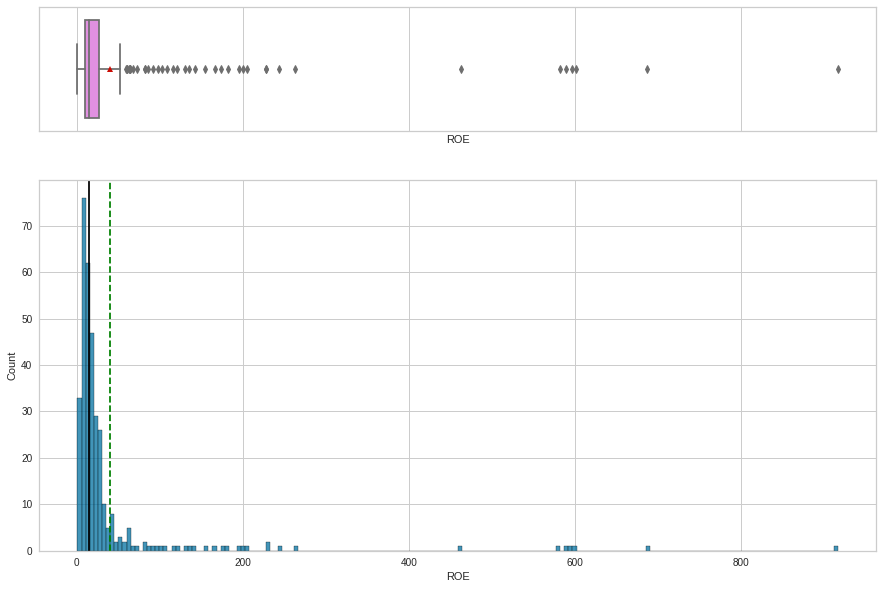

```python
histogram_boxplot(df_SD, "ROE")
```

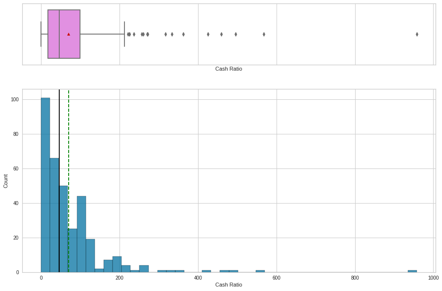

```python
histogram_boxplot(df_SD, "Cash Ratio")
```

- The average cash ratio is around 60-80.
- There are some outliers that start around 200.

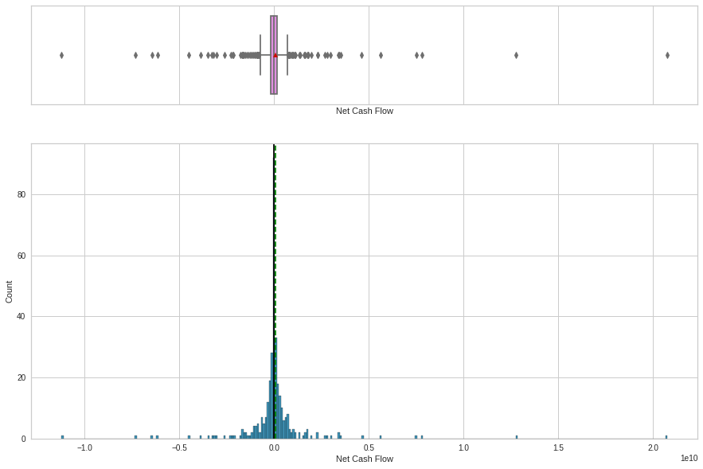

```python
histogram_boxplot(df_SD, "Net Cash Flow")
```

- The average cash flow seems to be around 0.
- There are outliers on the positive and negative side.

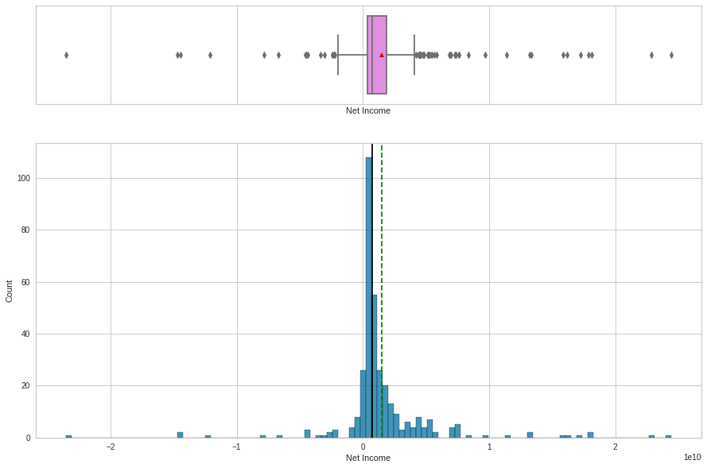

```python
histogram_boxplot(df_SD, "Net Income")
```

- The average cash flow seems to be a little above 0.
- There are outliers on the positive and negative side.

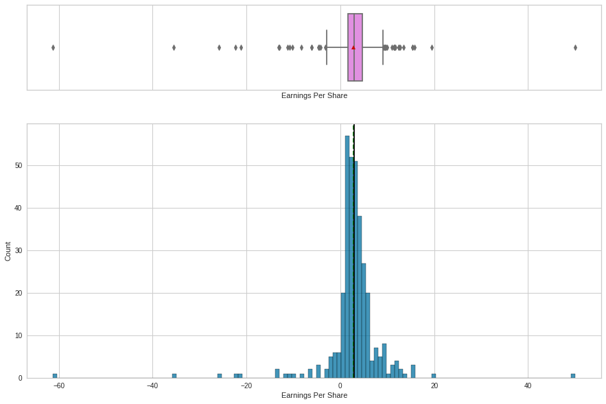

```python
histogram_boxplot(df_SD, "Earnings Per Share")
```

- The average is around 2 or 3 and there are outliers in the postive and negative side.

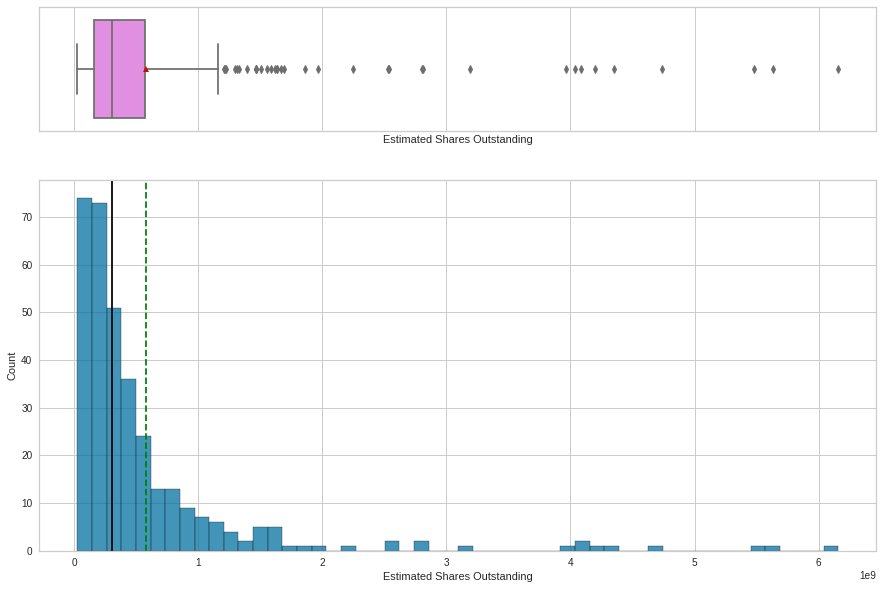

```python
histogram_boxplot(df_SD, "Estimated Shares Outstanding")
```

- The average shares outstanding is a little above 0.
- There are alot of outliers starting a little above 1.

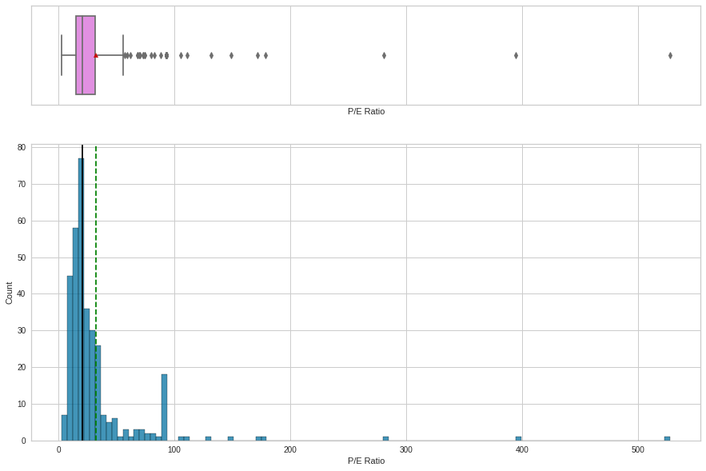

```python
histogram_boxplot(df_SD, "P/E Ratio")
```

- The average is around 30.
- There are many outliers starting around 50.

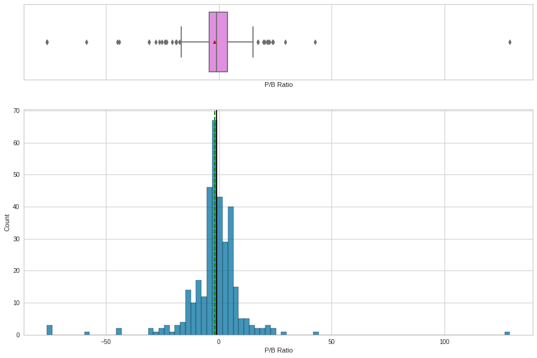

```python
histogram_boxplot(df_SD, "P/B Ratio")
```

- The average is around 0.
- There are outliers in the negative and positive regions.

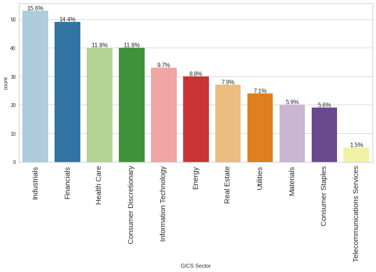

```python
labeled_barplot(df_SD, 'GICS Sector', perc=True)
```

- Industrials is the top at 15.6%, followed by Financials at 14.4% and Health Care at 11.8%

[figure not shown]

```python
labeled_barplot(df_SD, 'GICS Sub Industry', perc=True)
```

- Oil and Gas is the top GICS sub industry at 4.7% followed by REITs and industrial conglomerares.

**Bivariate Analysis**

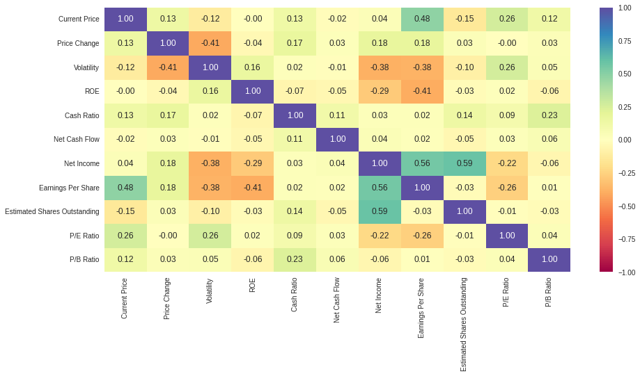

```python
plt.figure(figsize=(15, 7))
sns.heatmap(df_SD.corr(), annot=True, vmin=-1, vmax=1, fmt=".2f", cmap="Spectral")
plt.show()
```

- The top 3 positive correlations are: Net Income - Earnings Per Share, Net Income - Estimated Shares Outstanding, and Current Price - Earnings Per Share.

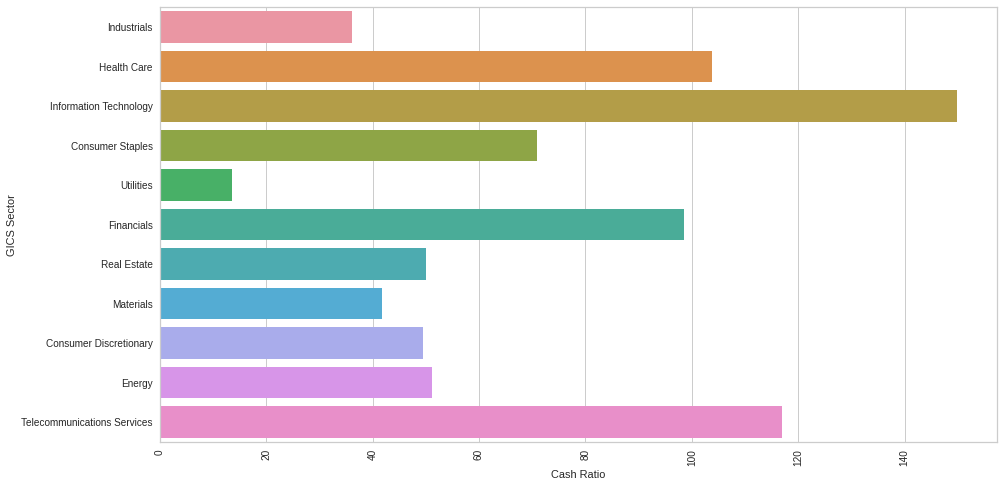

```python
plt.figure(figsize=(15,8))
sns.barplot(data=df_SD, x= "Cash Ratio", y= "GICS Sector", ci=False)
plt.xticks(rotation=90)
plt.show()
```

- The sector with the largest Cash ratio is Information Technology, followed by Telecommunication Services and Health Care.
- The sector with the least Cash ratio is Utilities.

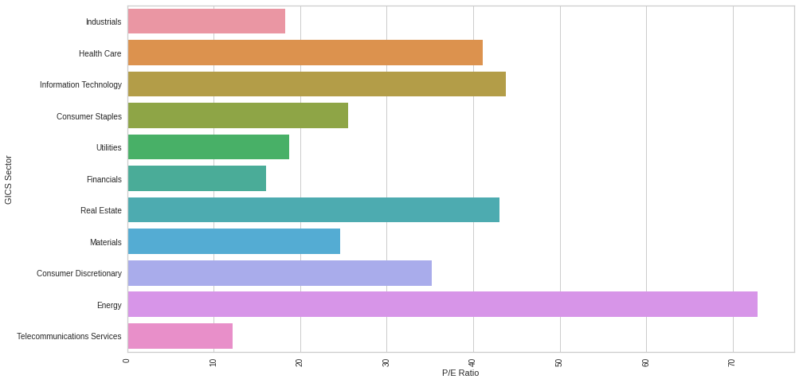

```python
plt.figure(figsize=(15,8))
sns.barplot(data=df_SD, x= "P/E Ratio", y= "GICS Sector", ci=False)
plt.xticks(rotation=90)
plt.show()
```

- The sector with the greatest P/E Ratio is Energy above 70.
- The next three sectors in order are IT, Real Estate, and Health Care.

## Data Preprocessing

- Duplicate value check
- Missing value treatment
- Outlier check
- Feature engineering (if needed)
- Any other preprocessing steps (if needed)

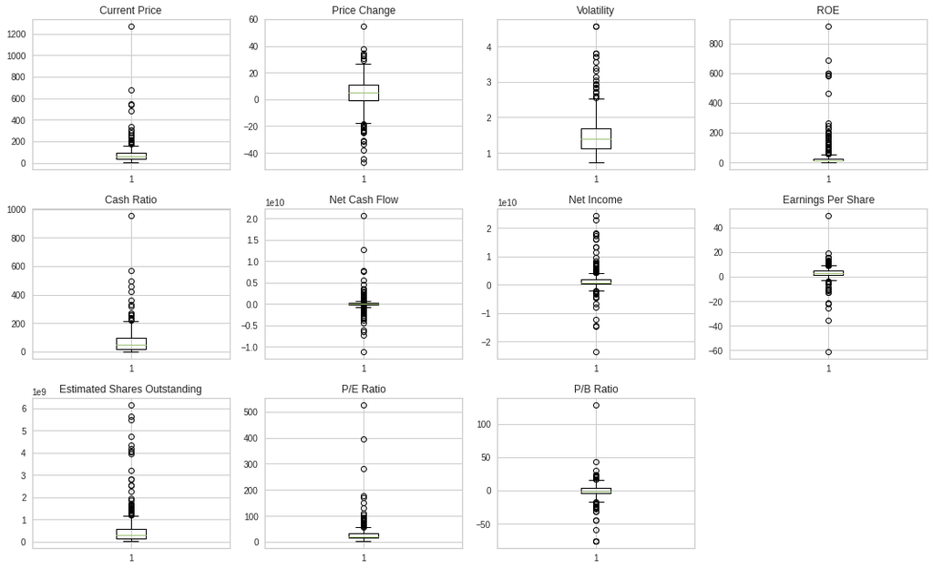

```python
Num_col = df_SD.select_dtypes(include=np.number).columns.tolist()
plt.figure(figsize=(15, 12))
for i, variable in enumerate(Num_col):
    plt.subplot(4, 4, i + 1)
    plt.boxplot(df_SD[variable], whis=1.5)
    plt.tight_layout()
    plt.title(variable)

plt.show()
```

- There are alot of outliers present but I will not treat them because they are proper values.

```python
scaler = StandardScaler()
subset = df_SD[Num_col].copy()
subset_scaled = scaler.fit_transform(subset)
```

```python
subset_scaled_dfSD = pd.DataFrame(subset_scaled, columns=subset.columns)
```

## EDA

- It is a good idea to explore the data once again after manipulating it.

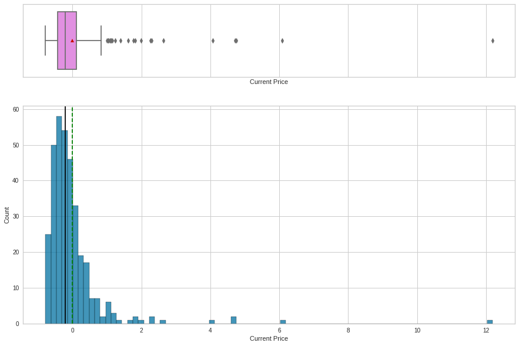

```python
histogram_boxplot(subset_scaled_dfSD, "Current Price")
```

- The average is a little below zero now.
- There are some outliers starting around 1 and goes all the way to 12.

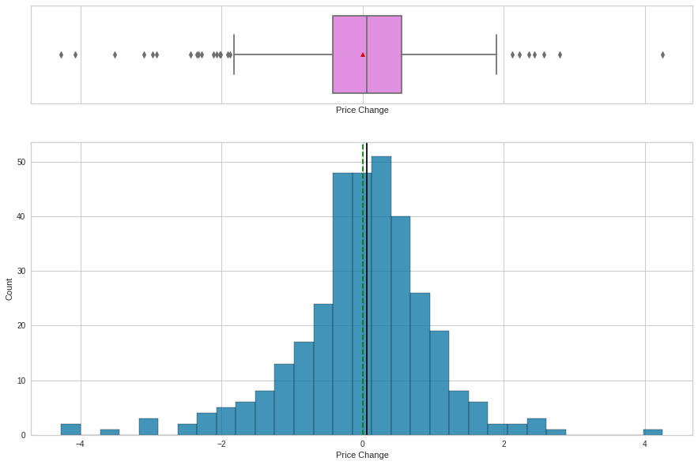

```python
histogram_boxplot(subset_scaled_dfSD, "Price Change")
```

- The average is around 0.
- There are outliers in the negative and positive regions.

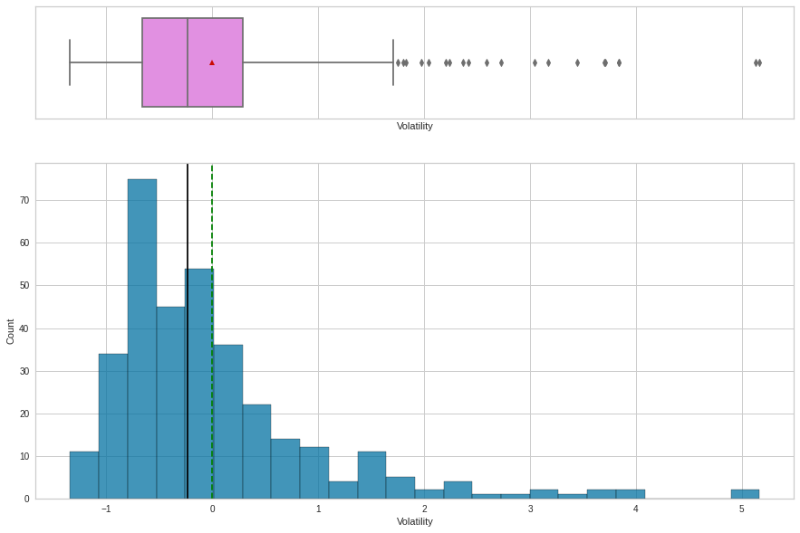

```python
histogram_boxplot(subset_scaled_dfSD, "Volatility")
```

- The average is just below 0.
- There are multiple outliers starting around 2.

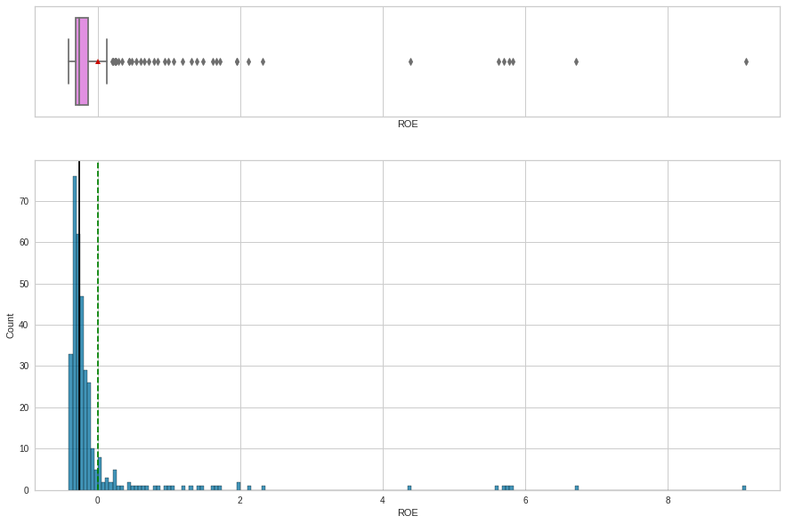

```python
histogram_boxplot(subset_scaled_dfSD, "ROE")
```

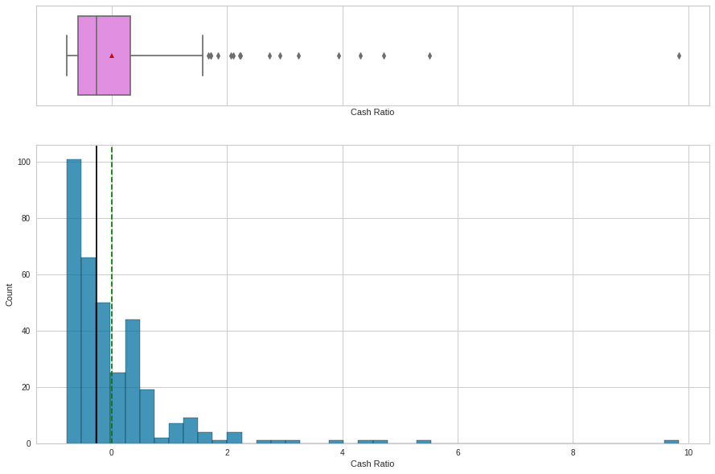

```python
histogram_boxplot(subset_scaled_dfSD, "Cash Ratio")
```

- The average is just below zero.
- All of the outliers appear in the upper quantrent of the graph.

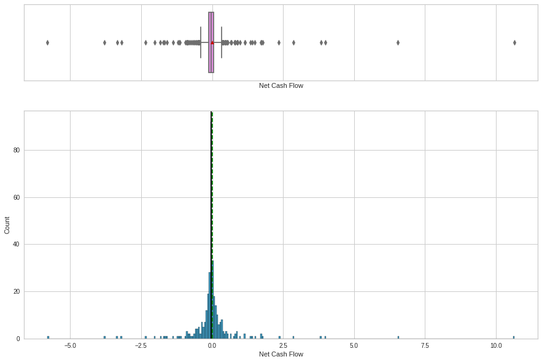

```python
histogram_boxplot(subset_scaled_dfSD, "Net Cash Flow")
```

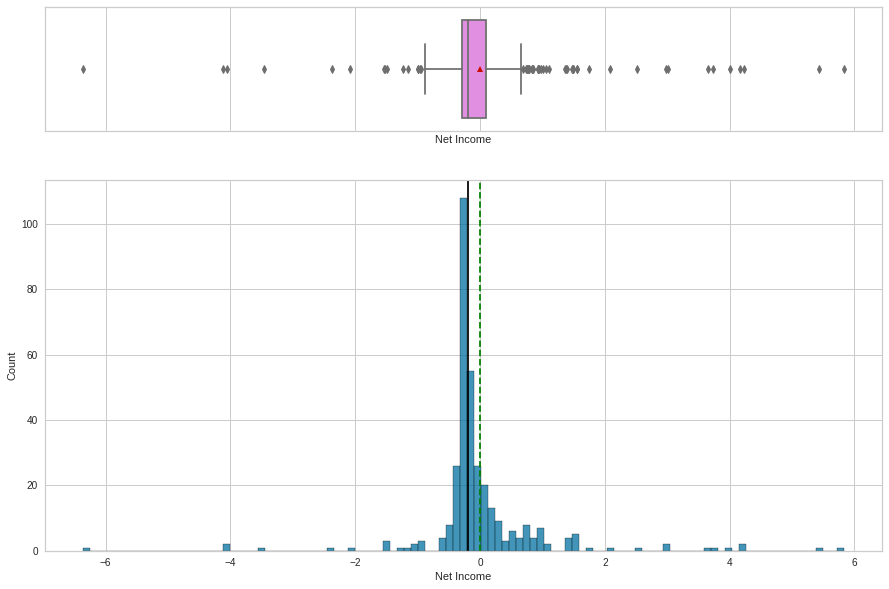

```python
histogram_boxplot(subset_scaled_dfSD, "Net Income")
```

- The average is just below zero and has outliers in both the negative and postive sections of the graph.

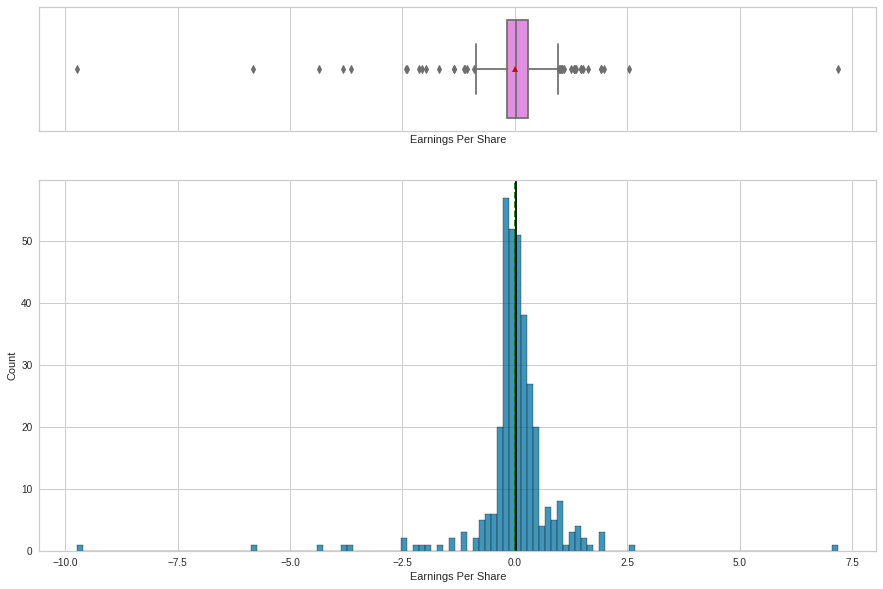

```python
histogram_boxplot(subset_scaled_dfSD, "Earnings Per Share")
```

- The average seems to be right at 0 and contains outliers in both the negative and positive sections.

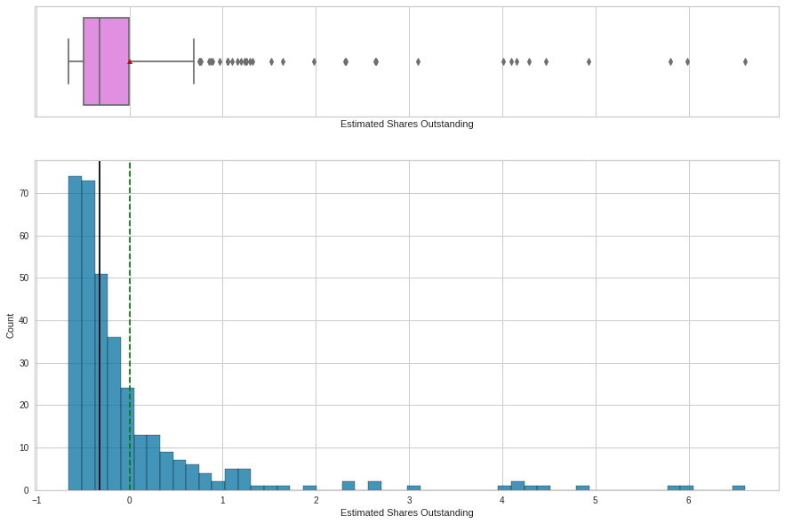

```python
histogram_boxplot(subset_scaled_dfSD, "Estimated Shares Outstanding")
```

- The average is just below zero and all of the outliers is above the 2nd quadrent of the graph.

## K-means Clustering

```python
Km_df_SD = subset_scaled_dfSD.copy()
```

```
Number of Clusters: 1 	Average Distortion: 2.5425069919221697
Number of Clusters: 2 	Average Distortion: 2.382318498894466
Number of Clusters: 3 	Average Distortion: 2.2683105560042285
Number of Clusters: 4 	Average Distortion: 2.179645269703779
Number of Clusters: 5 	Average Distortion: 2.132123786515153
Number of Clusters: 6 	Average Distortion: 2.0574742484876594
Number of Clusters: 7 	Average Distortion: 2.015675842333553
Number of Clusters: 8 	Average Distortion: 1.9711152823639846
Number of Clusters: 9 	Average Distortion: 1.924083709894684
Number of Clusters: 10 	Average Distortion: 1.8888322902671004
Number of Clusters: 11 	Average Distortion: 1.8036433604940472
Number of Clusters: 12 	Average Distortion: 1.7743897318847999
```

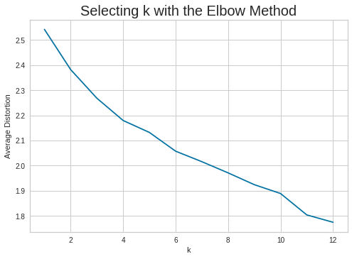

```python
clusters = range(1, 13)
meanDistortions = []
for k in clusters:
    model = KMeans(n_clusters=k)
    model.fit(subset_scaled_dfSD)
    prediction = model.predict(Km_df_SD)
    distortion = (sum(np.min(cdist(Km_df_SD, model.cluster_centers_, "euclidean"), axis=1))/ Km_df_SD.shape[0])
    meanDistortions.append(distortion)
    print("Number of Clusters:", k, "\tAverage Distortion:", distortion)
plt.plot(clusters, meanDistortions, "bx-")
plt.xlabel("k")
plt.ylabel("Average Distortion")
plt.title("Selecting k with the Elbow Method", fontsize=20)
plt.show()
```

- The value of k from the elbow curve seems to be 4 or 6.

```
For n_clusters = 2, silhouette score is 0.4484662124740991
For n_clusters = 3, silhouette score is 0.45494915445064904
For n_clusters = 4, silhouette score is 0.4524477668631469
For n_clusters = 5, silhouette score is 0.39563240713977266
For n_clusters = 6, silhouette score is 0.4168471220569999
For n_clusters = 7, silhouette score is 0.3849334132806394
For n_clusters = 8, silhouette score is 0.41476612263987034
For n_clusters = 9, silhouette score is 0.2100688281064458
For n_clusters = 10, silhouette score is 0.40732080223555106
For n_clusters = 11, silhouette score is 0.16872606524430464
For n_clusters = 12, silhouette score is 0.15664775859867333
```

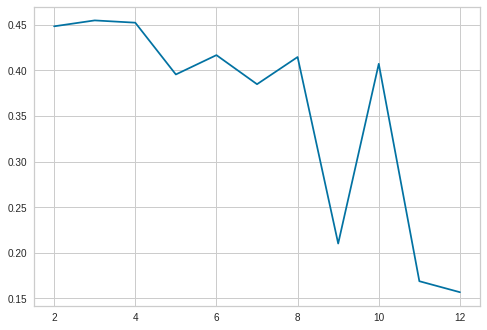

```python
sil_score = []
cluster_list = list(range(2, 13))
for n_clusters in cluster_list:
    clusterer = KMeans(n_clusters=n_clusters)
    preds = clusterer.fit_predict((subset_scaled_dfSD))
    score = silhouette_score(Km_df_SD, preds)
    sil_score.append(score)
    print("For n_clusters = {}, silhouette score is {}".format(n_clusters, score))

plt.plot(cluster_list, sil_score)
```

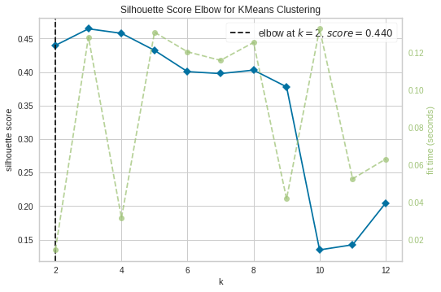

```python
model = KMeans(random_state=1)
visualizer = KElbowVisualizer(model, k=(2, 13), metric="silhouette", timings=True)
visualizer.fit(Km_df_SD)
visualizer.show()
```

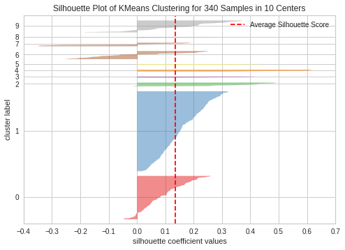

```python
visualizer = SilhouetteVisualizer(KMeans(10, random_state=1))
visualizer.fit(Km_df_SD)
visualizer.show()
```

**Final Model**

```python
kmeans = KMeans(n_clusters=10, random_state=0)
kmeans.fit(Km_df_SD)
```

```
KMeans(n_clusters=10, random_state=0)
```

```python
df_SD1 = df_SD.copy()
Km_df_SD["K_M_segments"] = kmeans.labels_
df_SD1["K_M_segments"] = kmeans.labels_
```

**Cluster Profile**

```python
KMcluster_profile = df_SD1.groupby("K_M_segments").mean()
```

```python
KMcluster_profile["count_in_each_segment"] = (df_SD1.groupby("K_M_segments")["Security"].count().values)
```

```python
KMcluster_profile.style.highlight_max(color="Yellow", axis=0)
```

| K_M_segments | Current Price | Price Change | Volatility | ROE | Cash Ratio | Net Cash Flow | Net Income | Earnings Per Share | Estimated Shares Outstanding | P/E Ratio | P/B Ratio | count_in_each_segment |
| --- | --- | --- | --- | --- | --- | --- | --- | --- | --- | --- | --- | --- |
| 0 | 83.082001 | 0.240051 | 1.321516 | 28.484277 | 45.396226 | 109619081.761006 | 1874388805.031446 | 4.650409 | 380271186.520189 | 20.549021 | -4.927912 | 159 |
| 1 | 59.713801 | 12.639144 | 1.471110 | 20.750000 | 64.741071 | -108663089.285714 | 1139007437.500000 | 2.511339 | 520174383.131250 | 27.617941 | -0.503338 | 112 |
| 2 | 35.263847 | -16.175693 | 2.841300 | 49.769231 | 48.153846 | -135215038.461538 | -2525946153.846154 | -6.514231 | 482428533.751538 | 77.817252 | 1.618150 | 26 |
| 3 | 46.672222 | 5.166566 | 1.079367 | 25.000000 | 58.333333 | -3040666666.666667 | 14848444444.444445 | 3.435556 | 4564959946.222222 | 15.596051 | -6.354193 | 9 |
| 4 | 108.304002 | 10.737770 | 1.165694 | 566.200000 | 26.600000 | -278760000.000000 | 687180000.000000 | 1.548000 | 349607057.720000 | 34.898915 | -16.851358 | 5 |
| 5 | 327.006671 | 21.917380 | 2.029752 | 4.000000 | 106.000000 | 698240666.666667 | 287547000.000000 | 0.750000 | 366763235.300000 | 400.989188 | -5.322376 | 3 |
| 6 | 89.124314 | 10.571348 | 1.826073 | 29.823529 | 344.470588 | 844445294.117647 | 958283058.823529 | 1.914118 | 828171163.663529 | 48.684688 | 9.215861 | 17 |
| 7 | 624.079986 | 2.395375 | 1.557535 | 22.400000 | 178.400000 | -295455600.000000 | 969671800.000000 | 19.268000 | 57832481.588000 | 42.051273 | 41.645997 | 5 |
| 8 | 25.640000 | 11.237908 | 1.322355 | 12.500000 | 130.500000 | 16755500000.000000 | 13654000000.000000 | 3.295000 | 2791829362.100000 | 13.649696 | 1.508484 | 2 |
| 9 | 24.485001 | -13.351992 | 3.482611 | 802.000000 | 51.000000 | -1292500000.000000 | -19106500000.000000 | -41.815000 | 519573983.250000 | 60.748608 | 1.565141 | 2 |

```python
for cl in df_SD1["GICS Sector"].unique():
    print("In cluster {}, the following companies are present:".format(cl))
    print(df_SD1[df_SD1["GICS Sector"] == cl]["Security"].unique())
    print()
```

```
In cluster Industrials, the following companies are present:
['American Airlines Group' 'Alaska Air Group Inc' 'Allegion' 'AMETEK Inc'
 'Arconic Inc' 'Boeing Company' 'Caterpillar Inc.'
 'C. H. Robinson Worldwide' 'Cummins Inc.' 'CSX Corp.' 'Delta Air Lines'
 'Deere & Co.' 'Danaher Corp.' 'Dun & Bradstreet' 'Dover Corp.'
 'Equifax Inc.' 'Eaton Corporation' "Expeditors Int'l" 'Fastenal Co'
 'Fortune Brands Home & Security' 'Fluor Corp.' 'Flowserve Corporation'
 'General Dynamics' 'Grainger (W.W.) Inc.' "Honeywell Int'l Inc."
 'Illinois Tool Works' 'J. B. Hunt Transport Services'
 'Jacobs Engineering Group' 'Kansas City Southern' 'Leggett & Platt'
 'L-3 Communications Holdings' 'Lockheed Martin Corp.'
 'Southwest Airlines' 'Masco Corp.' '3M Company' 'Nielsen Holdings'
 'Norfolk Southern Corp.' 'Pitney-Bowes' 'PACCAR Inc.' 'Pentair Ltd.'
 'Quanta Services Inc.' 'Ryder System' 'Robert Half International'
 'Roper Industries' 'Republic Services Inc' 'Stericycle Inc'
 'United Continental Holdings' 'Union Pacific' 'United Parcel Service'
 'United Technologies' 'Verisk Analytics' 'Waste Management Inc.'
 'Xylem Inc.']

In cluster Health Care, the following companies are present:
['AbbVie' 'Abbott Laboratories' 'Alexion Pharmaceuticals' 'Amgen Inc'
 'Anthem Inc.' 'Baxter International Inc.' 'Bard (C.R.) Inc.'
 'BIOGEN IDEC Inc.' 'Bristol-Myers Squibb' 'Boston Scientific'
 'Celgene Corp.' 'CIGNA Corp.' 'Centene Corporation'
 'The Cooper Companies' 'Quest Diagnostics' 'DaVita Inc.'
 'Edwards Lifesciences' 'Gilead Sciences' 'HCA Holdings' 'Henry Schein'
 'Humana Inc.' 'IDEXX Laboratories' 'Intuitive Surgical Inc.'
 'Laboratory Corp. of America Holding' 'Lilly (Eli) & Co.' 'Merck & Co.'
 'Mettler Toledo' 'Mylan N.V.' 'Pfizer Inc.' 'Regeneron' 'Stryker Corp.'
 'Thermo Fisher Scientific' 'Universal Health Services, Inc.'
 'United Health Group Inc.' 'Varian Medical Systems'
 'Vertex Pharmaceuticals Inc' 'Waters Corporation' 'Dentsply Sirona'
 'Zimmer Biomet Holdings' 'Zoetis']

In cluster Information Technology, the following companies are present:
['Adobe Systems Inc' 'Analog Devices, Inc.' 'Alliance Data Systems'
 'Akamai Technologies Inc' 'Applied Materials Inc' 'Amphenol Corp'
 'Activision Blizzard' 'Broadcom' 'Cognizant Technology Solutions'
 'Citrix Systems' 'eBay Inc.' 'Facebook'
 'Fidelity National Information Services' 'Fiserv Inc' 'FLIR Systems'
```

[output cut: 79 more lines]

```

In cluster Energy, the following companies are present:
['Apache Corporation' 'Anadarko Petroleum Corp' 'Baker Hughes Inc'
 'Chesapeake Energy' 'Cabot Oil & Gas' 'Chevron Corp.' 'Concho Resources'
 'Devon Energy Corp.' 'EOG Resources' 'EQT Corporation' 'Halliburton Co.'
 'Hess Corporation' 'Kinder Morgan' 'Marathon Petroleum'
 'Marathon Oil Corp.' 'Murphy Oil' 'Noble Energy Inc'
 'Newfield Exploration Co' 'National Oilwell Varco Inc.' 'ONEOK'
 'Occidental Petroleum' 'Phillips 66' 'Range Resources Corp.'
 'Spectra Energy Corp.' 'Southwestern Energy' 'Tesoro Petroleum Co.'
 'Valero Energy' 'Williams Cos.' 'Cimarex Energy' 'Exxon Mobil Corp.']

In cluster Telecommunications Services, the following companies are present:
['CenturyLink Inc' 'Frontier Communications' 'Level 3 Communications'
 'AT&T Inc' 'Verizon Communications']
```

```python
df_SD1.groupby(["K_M_segments", "GICS Sector"])['Security'].count()
```

```
K_M_segments  GICS Sector
0             Consumer Discretionary         19
              Consumer Staples                9
              Energy                          2
              Financials                     30
              Health Care                    16
              Industrials                    34
              Information Technology          6
              Materials                       9
              Real Estate                    11
              Telecommunications Services     1
              Utilities                      22
1             Consumer Discretionary         14
              Consumer Staples                6
              Energy                          3
              Financials                     14
              Health Care                    15
              Industrials                    17
              Information Technology         17
              Materials                       8
              Real Estate                    15
              Telecommunications Services     1
              Utilities                       2
2             Energy                         21
              Industrials                     1
              Information Technology          2
              Materials                       2
3             Consumer Discretionary          1
              Consumer Staples                1
              Energy                          1
              Financials                      3
              Health Care                     1
              Telecommunications Services     2
4             Consumer Discretionary          1
              Consumer Staples                2
              Financials                      1
              Industrials                     1
5             Consumer Discretionary          1
              Health Care                     1
              Information Technology          1
6             Consumer Discretionary          2
              Consumer Staples                1
              Energy                          1
              Health Care                     5
              Information Technology          5
              Materials                       1
              Real Estate                     1
              Telecommunications Services     1
7             Consumer Discretionary          2
              Health Care                     2
              Information Technology          1
8             Financials                      1
              Information Technology          1
9             Energy                          2
Name: Security, dtype: int64
```

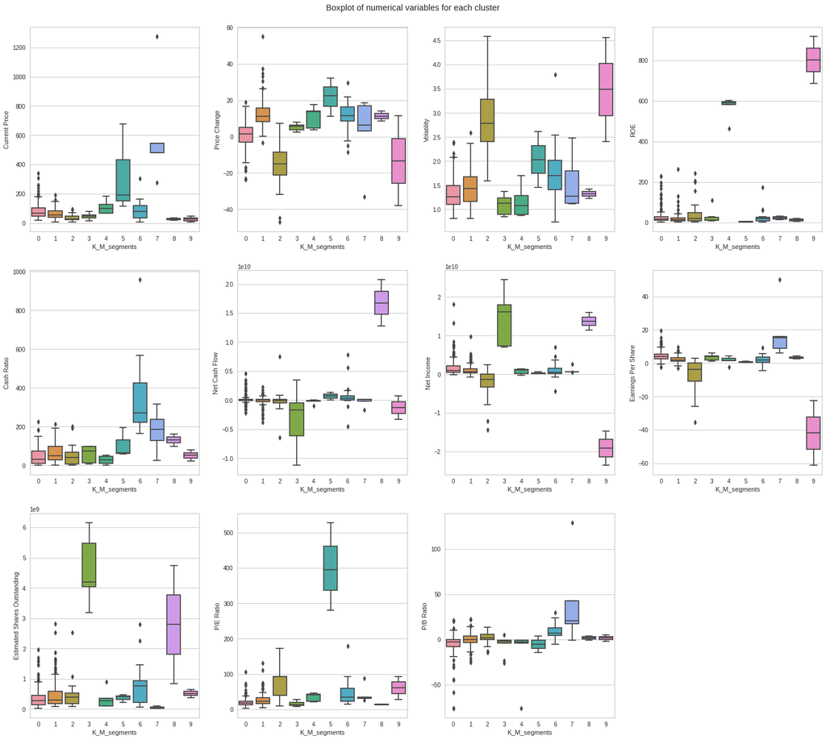

```python
plt.figure(figsize=(20, 18))
plt.suptitle("Boxplot of numerical variables for each cluster")
num_col = df_SD.select_dtypes(include=np.number).columns.tolist()
for i, variable in enumerate(num_col):
    plt.subplot(3, 4, i + 1)
    sns.boxplot(data=df_SD1, x="K_M_segments", y=variable)
plt.tight_layout(pad=2.0)
```

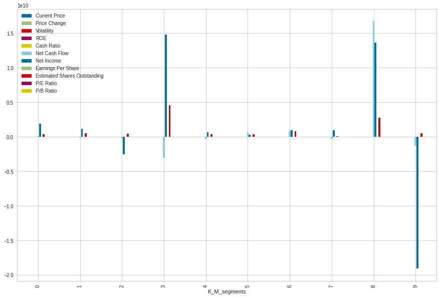

```python
df_SD1.groupby("K_M_segments").mean().plot.bar(figsize=(15, 10))
```

**Insights**